# Tromp tweets

# 4. The quote tweet is dead

Another place we can spot a difference is in Trump’s anachronistic behavior of “manually retweeting” people by copy-pasting their tweets, then surrounding them with quotation marks. These are known as quote tweets (https://www.theringer.com/tech/2018/5/2/17311616/twitter-retweet-quote-endorsement-function-trolls).

[ToddVaziri2](https://twitter.com/realDonaldTrump/status/758512401629192192)

Almost all the quote tweets are posted from the Android. After this plot, we’ll filter out the quote tweets in the remaining by-word analyses because they contain text from followers that may not be representative of Trump’s tweets.

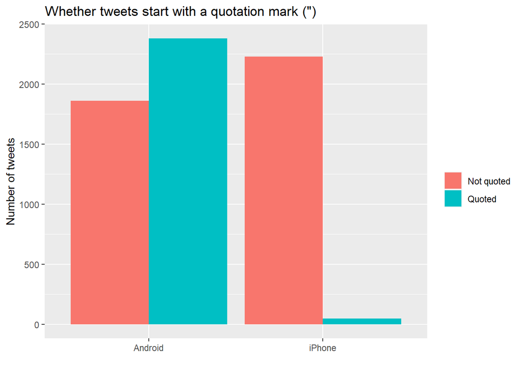

```r
# Load stringr
library(stringr)

# Plot the number of tweets with and without quotes by device
cleaned_tweets %>%
  count(source,
        quoted = ifelse(str_detect(text, '^"'), "Quoted", "Not quoted")) %>%
  ggplot(aes(source, n, fill = quoted)) +
  geom_bar(stat = "identity", position = "dodge") +
  labs(x = "", y = "Number of tweets", fill = "") +
  ggtitle('Whether tweets start with a quotation mark (")')
```

## Task 4: Instructions

Create a bar plot of the number of tweets that are quoted and not quoted from each device.

1-Use count() to determine the number of tweets quoted or not quoted by each device. 2-Within ifelse(), set the true outcome to “Quoted”, and the false outcome to “Not quoted”. 3-Add source as the x-variable and the number of quoted and not quoted tweets as the y-variable. Set fill= to whether the tweet was quoted or not. 4-Set the correct parameter for position= within geom_bar() to display the bars for each device side-by-side.

### HINT

You can create, group, and count data in variable b within the call to count(). Use fill() in the ggplot aesthetics to color-code the groups in variable b, (in this example, Snowing or Not snowing), like so:

data %>% count(a, b = ifelse(str_detect(text, ’^“’),”Snowing”, “Not snowing”)) %>% ggplot(aes(a, n, fill = b)) + geom_bar() + …. Don’t forget that the output of count() is column n.

# 5. Links and pictures

Another place we see a difference between the iPhone and Android tweets is in the sharing of links or pictures. It turns out that tweets from the iPhone were way more likely to contain either a picture or a link. This also makes sense with our narrative: iPhone (presumably run by the campaign) tends to write “announcement” tweets about events, like this: [ToddVaziri3](https://twitter.com/realDonaldTrump/status/762110918721310721)

While Android (Trump himself) tends to write picture-less tweets like:

[ToddVaziri3](https://twitter.com/realDonaldTrump/status/762400869858115588)

```r
# Count the number of tweets with and without picture/links by device
tweet_picture_counts <- cleaned_tweets %>%
  filter(!str_detect(text, '^"')) %>%
  count(source,
        picture = ifelse(str_detect(text, "t.co"),
                         "Picture/link", "No picture/link"))
print(tweet_picture_counts)
```

```
## # A tibble: 4 × 3
##   source  picture             n
##   <chr>   <chr>           <int>
## 1 Android No picture/link  1808
## 2 Android Picture/link       51
## 3 iPhone  No picture/link   702
## 4 iPhone  Picture/link     1526
```

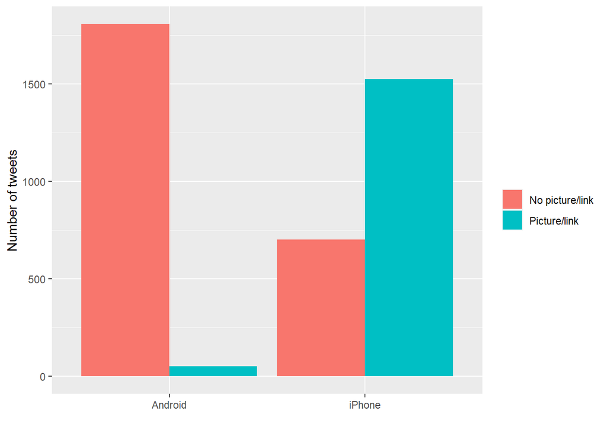

```r
# Make a bar plot
ggplot(tweet_picture_counts, aes(x=source, y=n, fill = picture)) +
  geom_bar(stat = "identity", position = "dodge") +
  labs(x = "", y = "Number of tweets", fill = "")
```

##Task 5: Instructions Create a bar plot of the number of tweets that do and do not have a picture/link from each device.

1-After filtering out all the quote tweets, count the number of tweets with a picture/link by each device. 2-Add the correct stringr function within ifelse() to detect the pattern, t.co, in the text column. 3-Using the new data frame, add source as the x-variable and the number of tweets as the y-variable. Set fill= to whether or not the tweet had a picture/link. 4-Set the correct parameter for position= within geom_bar() to display the bars for each device side-by-side.

### HINT

There are a lot of great functions in stringr that help you work with strings. We’ve used str_detect() in the last two tasks to detect patterns in strings. The output of str_detect() is TRUE or FALSE, which works well with other functions for filtering and conditional statements.

Don’t forget that the output of count() is column n.

#6. Comparison of words Now that we’re sure there is a difference between these two platforms, what can we say about the difference in the content of the tweets? We’ll use the tidytext package that Julia Silge and I developed. We start by dividing lines of text into individual words using unnest_tokens() (see this vignette for more), and by removing some common “stopwords”.

```r
# Load the tidytext package
library(tidytext)

# Create a regex pattern
reg <- "([^A-Za-z\\d#@']|'(?![A-Za-z\\d#@]))"

# Unnest the text strings into a data frame of words
tweet_words <- cleaned_tweets %>%
  filter(!str_detect(text, '^"')) %>%
  mutate(text = str_replace_all(text, "https://t.co/[A-Za-z\\d]+|&amp;", "")) %>%
  unnest_tokens(word, text, token = "regex", pattern = reg) %>%
  filter(!word %in% stop_words$word,
         str_detect(word, "[a-z]"))

# Inspect the first six rows of tweet_words
head(tweet_words)
```

```
## # A tibble: 6 × 4
##    id_str source  created_at          word
##     <dbl> <chr>   <dttm>              <chr>
## 1 6.83e17 Android 2015-12-31 23:21:49 happy
## 2 6.83e17 Android 2015-12-31 23:21:49 healthy
## 3 6.83e17 Android 2015-12-31 23:21:49 finally
## 4 6.83e17 Android 2015-12-31 23:21:49 america
## 5 6.83e17 Android 2015-12-31 23:21:49 safe
## 6 6.83e17 Android 2015-12-31 23:11:35 department
```

## Task 6: Instructions

Create a new data frame of words from all the tweets.

1-Add the correct regex pattern to remove quote tweets. Look back at previous tasks for help. 2-Use unnest_tokens() to transform the lines of text into words (in a new word column) using the regex pattern in reg. 3-Remove any stopwords using the correct column from the stop_words data frame.

The data frame stop_words is loaded with tidytext. The column word contains the “stopwords” in the data frame stop_words.

### HINT

Regex stands for REGular EXpression and is a sequence of characters that define a search pattern.

To unnest text in column t, directed by a regex pattern given in reg_pat, where each word is placed in a new column w, you would use unnest_tokens() like so:

data %>% unnest_tokens(w, t, token = “regex”, pattern = reg_pat)